# The EZ Bayesian Hierarchical DDM (EZBHDDM)

# Background

### The Drift Diffusion Model

The Drift Diffusion Model (DDM) is a process model that describes the choices and response times (RTs) observed in binary decision tasks as the result of a latent evidence accumulation process. In its simplest form, the model uses three parameters to describe this process: a drift rate, a boundary separation, and a non-decision time (described below), all of which have been shown to correlate with relevant aspects of the experimental design.

- **Non-decision time**: Captures a constant time offset to the RT to account that is attributed to processes other than the decision process itself (e.g., motor response time, perceptual processing time, etc.).
- **Boundary separation**: Captures the distance between the two opposite boundaries capturing the two possible choices. This parameter has been shown to describe the accuracy/speed trade-off in the decision process (i.e., lower boundary separation leads to faster responses but lower accuracy, and vice versa).
- **Drift rate**: Captures the average step size and direction of the evidence acumulation process towards either of the two boundaries. This parameter has been shown to correlate with the task difficulty (i.e., easier tasks have higher drift rates, and vice versa).

# A Bayesian hierarchical EZ-DDM implementation

### JAGS base model

```r
modelFile <- here("JAGS", "basic_model.bug")

model <- write("
model {
    #===================================================================
    # HIERARCHICAL PRIORS: Population-level parameters
    #===================================================================
    # Population means
    drift_mean ~ dnorm(0.50, pow(0.50, -2))
    bound_mean ~ dnorm(1.50, pow(0.20, -2)) T(0.10, 3.00)
    nondt_mean ~ dnorm(0.30, pow(0.10, -2)) T(0.05, )

    # Population standard deviations (between-subject variability)
    drift_sd ~ dunif(0.01, 1.00)
    bound_sd ~ dunif(0.01, 0.50)
    nondt_sd ~ dunif(0.01, 0.20)

    #===================================================================
    # INDIVIDUAL PARAMETERS AND LIKELIHOOD
    #===================================================================
    for (p in 1:N) {

        #---------------------------------------------------------------
        # Individual DDM parameters drawn from hierarchical distributions
        #---------------------------------------------------------------
        drift[p] ~ dnorm(drift_mean, pow(drift_sd, -2))
        bound[p] ~ dnorm(bound_mean, pow(bound_sd, -2)) T(0.10, 3.00)
        nondt[p] ~ dnorm(nondt_mean, pow(nondt_sd, -2)) T(0.05, )

        #---------------------------------------------------------------
        # EZ-DDM Forward Equations: Parameters -> Expected summary stats
        #---------------------------------------------------------------
        # Intermediate term
        ey[p] <- exp(-bound[p] * drift[p])

        # Expected proportion correct
        Pc[p] <- 1 / (1 + ey[p])

        # Expected mean decision time
        MDT[p] <- (bound[p] / (2 * drift[p])) * (1 - ey[p]) / (1 + ey[p])

        # Expected mean reaction time (decision time + non-decision time)
        MRT[p] <- MDT[p] + nondt[p]

        # RT precision (inverse variance)
        PRT[p] <- 2 * pow(drift[p], 3) / bound[p] *
                  pow(ey[p] + 1, 2) /
                  (2 * -bound[p] * drift[p] * ey[p] - pow(ey[p], 2) + 1)

        #---------------------------------------------------------------
        # Sampling Distributions: Likelihood of observed summary stats
        #---------------------------------------------------------------
        # Number correct ~ Binomial(nTrials, Pc)
        correct[p] ~ dbin(Pc[p], nTrials[p])

        # Mean RT ~ Normal(MRT, precision = PRT * nTrials)
        meanRT[p] ~ dnorm(MRT[p], PRT[p] * nTrials[p])

        # Variance of RT ~ Normal(VRT, precision from sampling distribution)
        # Note: VRT = 1/PRT
        varRT[p] ~ dnorm(1/PRT[p], 0.5 * (nTrials[p] - 1) * pow(PRT[p], 2))
    }
}
", modelFile)
```

# Simulation studies:

We now present two short simulation studies to evaluate the parameter recovery of this hierarchical Bayesian EZ-DDM implementation.

We will generate `K` datasets, each with `P` participants and `nTrials` trials. For each dataset, we will generate random individual-level parameters for all three model parameters $\nu_p$, $\alpha_p$, and $\tau_p$ from the same true population distributions (with fixed true parameters $\mu_\nu$, $\mu_\alpha$, $\mu_\tau$, $\sigma_\nu$, $\sigma_\alpha$, $\sigma_\tau$).

```r
# Number of participants
P <- 20
# Number of trials per participant
nTrials <- 100
# Number of datasets (simulation replications)
K <- 100
```

```r
#===============================================================================
# True population parameters (FIXED across all K simulations)
#===============================================================================
true_pars <- list(
    drift_mean = 0.50,   # Population mean drift rate
    drift_sd   = 0.20,   # Between-subject SD of drift
    bound_mean = 1.50,   # Population mean boundary separation
    bound_sd   = 0.25,   # Between-subject SD of boundary
    nondt_mean = 0.30,   # Population mean non-decision time
    nondt_sd   = 0.05    # Between-subject SD of non-decision time
)
```

## Simulation study 1: Trial-level data generation

In this simulation study, we generate trial-level data by emulating the DDM random walk process, then compute summary statistics from those trials. This is the more rigorous approach that tests whether the EZ approximations hold for realistic data.

### Source custom functions

```r
# Source the custom functions for data generation
source(here("JAGS", "src", "generate_trialData.R"))
source(here("JAGS", "src", "calculate_sumStats.R"))
```

### Data generation

```r
#===============================================================================
# Generate K datasets with trial-level data
#===============================================================================

# Initialize 3D array to store summary statistics
# Dimensions: [P participants] x [5 columns] x [K datasets]
# Columns: sub, nTrials, sum_correct, meanRT, varRT
sumStats_trialLevel <- array(NA, dim = c(P, 5, K),
                              dimnames = list(
                                  participant = 1:P,
                                  stat = c("sub", "nTrials", "sum_correct", "meanRT", "varRT"),
                                  dataset = 1:K
                              ))

# Also store true individual parameters for recovery checks
true_individual <- array(NA, dim = c(P, 3, K),
                          dimnames = list(
                              participant = 1:P,
                              param = c("drift", "bound", "nondt"),
                              dataset = 1:K
                          ))
```

```r
#===============================================================================
# Generate or load simulated data
#===============================================================================

# File path for cached data
dataFile <- here("JAGS", "demos", "simulation-study", "simplest_model",
                 paste0("simData_trialLevel_P", P, "_T", nTrials, "_K", K, ".RData"))

# IF cached data exists, load them
#####################################!!!
if (file.exists(dataFile)) {

    load(dataFile)

# ELSE, generate new data
#####################################!!!
} else {

    # Initialize 3D array to store summary statistics
    sumStats_trialLevel <- array(NA, dim = c(P, 5, K),
                                  dimnames = list(
                                      participant = 1:P,
                                      stat = c("sub", "nTrials", "sum_correct", "meanRT", "varRT"),
                                      dataset = 1:K
                                  ))

    # Also store true individual parameters for recovery checks
    true_individual <- array(NA, dim = c(P, 3, K),
                              dimnames = list(
                                  participant = 1:P,
                                  param = c("drift", "bound", "nondt"),
                                  dataset = 1:K
                              ))

    # Loop over K datasets
    for (k in 1:K) {

        # Set seed for reproducibility
        set.seed(k)

        #-----------------------------------------------------------------------
        # Step 1: Generate true individual parameters from hierarchical distributions
        #-----------------------------------------------------------------------
        drift_true <- rnorm(P, true_pars$drift_mean, true_pars$drift_sd)

        # Boundary: truncated to [0.1, 3.0]
        bound_true <- numeric(P)
        for (p in 1:P) {
            repeat {
                b <- rnorm(1, true_pars$bound_mean, true_pars$bound_sd)
                if (b > 0.1 && b < 3.0) { bound_true[p] <- b; break }
            }
        }

        # Non-decision time: truncated to [0.05, Inf)
        nondt_true <- numeric(P)
        for (p in 1:P) {
            repeat {
                t <- rnorm(1, true_pars$nondt_mean, true_pars$nondt_sd)
                if (t > 0.05) { nondt_true[p] <- t; break }
            }
        }

        # Store true individual parameters
        true_individual[, "drift", k] <- drift_true
        true_individual[, "bound", k] <- bound_true
        true_individual[, "nondt", k] <- nondt_true

        #-----------------------------------------------------------------------
        # Step 2: Generate trial-level data using DDM random walk emulation
        #-----------------------------------------------------------------------
        parameter_set <- list(
            drift = drift_true,
            bound = bound_true,
            nondt = nondt_true
        )

        trial_data <- sample_data(nPart = P,
                                   nTrials = nTrials,
                                   parameter_set = parameter_set,
                                   prevent_zero_accuracy = TRUE)

        #-----------------------------------------------------------------------
        # Step 3: Compute summary statistics from trial-level data
        #-----------------------------------------------------------------------
        sumstats <- getStatistics(trial_data)

        # Store in 3D array
        sumStats_trialLevel[, "sub", k]         <- sumstats[, "sub"]
        sumStats_trialLevel[, "nTrials", k]     <- nTrials
        sumStats_trialLevel[, "sum_correct", k] <- sumstats[, "sum_correct"]
        sumStats_trialLevel[, "meanRT", k]      <- sumstats[, "meanRT"]
        sumStats_trialLevel[, "varRT", k]       <- sumstats[, "varRT"]

        # Progress indicator
        if (k %% 10 == 0) cat("Dataset", k, "of", K, "complete\n")
    }

    # Save to .RData file
    dir.create(dirname(dataFile), showWarnings = FALSE, recursive = TRUE)
    save(sumStats_trialLevel, true_individual, true_pars, P, nTrials, K,
         file = dataFile)
}
```

### Inspect generated data

Let us validate the data generation process by inspecting the content of the summary statistics stored for each datasets

```r
# Print the first 6 rows of the first dataset
print(head(sumStats_trialLevel[, , 1]))
```

```
##            stat
## participant sub nTrials sum_correct    meanRT      varRT
##           1   1     100          74 1.0541938 0.53220138
##           2   2     100          77 1.0085819 0.25547229
##           3   3     100          60 0.7919382 0.12261851
##           4   4     100          71 0.5817132 0.04182498
##           5   5     100          69 0.9344822 0.21507775
##           6   6     100          61 0.8308952 0.20806725
```

Now, let us check the distribution of accuracy rates across all datasets.

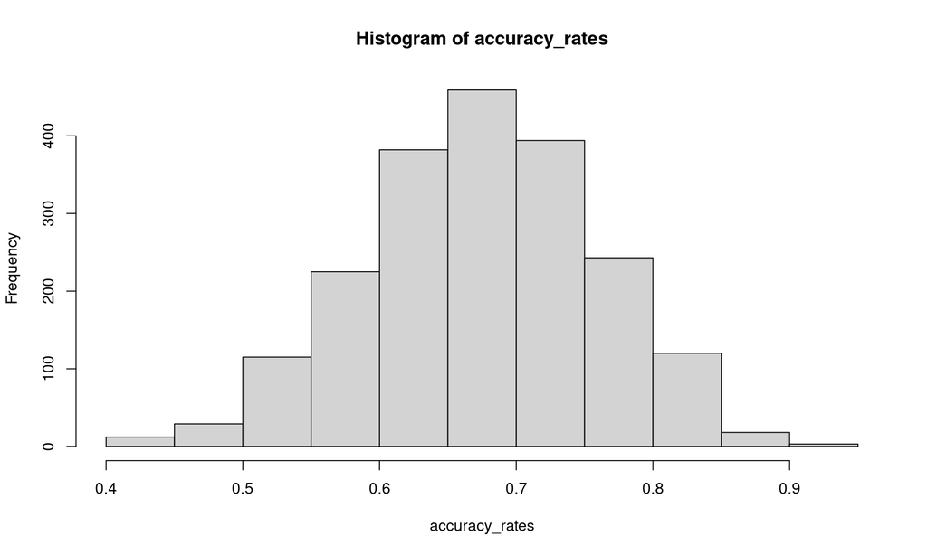

```r
# Check distribution of accuracy rates across all datasets
accuracy_rates <- sumStats_trialLevel[, "sum_correct", ] / nTrials
hist(accuracy_rates)
```

The mean accuracy rate observed across all datasets is 0.679 with a standard deviation of 0.084 and a range of 0.4 to 0.94.

### Model implementation in JAGS

We fit the hierarchical EZ-DDM to each of the K generated datasets and store the posterior estimates for parameter recovery analysis.

```r
library(R2jags)
source(here("JAGS", "src", "calculate_Rhat.R"))
```

```r
#===============================================================================
# Fit model or load cached results
#===============================================================================

# File path for cached results
resultsFile <- here("JAGS", "demos", "simulation-study", "simplest_model",
                    paste0("simResults_trialLevel_P", P, "_T", nTrials, "_K", K, ".RData"))

# IF cached results exist, load them
#####################################!!!
if (file.exists(resultsFile)) {

    load(resultsFile)

# ELSE, fit the model to all K datasets
} else {

    # JAGS sampling settings
    n.chains  <- 4
    n.iter    <- 5000
    n.burnin  <- 1000
    n.thin    <- 1

    # Parameters to monitor
    parameters <- c('drift_mean', 'drift_sd', 'bound_mean', 'bound_sd',
                    'nondt_mean', 'nondt_sd', 'drift', 'bound', 'nondt')

    # Initialize storage arrays
    pop_estimates <- array(NA, dim = c(6, K),
                           dimnames = list(param = c("drift_mean", "drift_sd",
                                                     "bound_mean", "bound_sd",
                                                     "nondt_mean", "nondt_sd"),
                                           dataset = 1:K))

    ind_estimates <- array(NA, dim = c(P, 3, K),
                           dimnames = list(participant = 1:P,
                                           param = c("drift", "bound", "nondt"),
                                           dataset = 1:K))

    rhat_max <- numeric(K)

    # Fit model to all K datasets
    for (k in 1:K) {
        set.seed(k + 1000)

        # Prepare data for JAGS
        data_toJAGS <- list(
            N        = P,
            nTrials  = rep(nTrials, P),
            correct  = sumStats_trialLevel[, "sum_correct", k],
            meanRT   = sumStats_trialLevel[, "meanRT", k],
            varRT    = sumStats_trialLevel[, "varRT", k]
        )

        # Initial values
        myinits <- replicate(n.chains, list(
            drift = rnorm(P, 0.5, 0.1),
            bound = runif(P, 1.0, 2.0),
            nondt = runif(P, 0.2, 0.4)
        ), simplify = FALSE)

        # Run JAGS
        samples <- jags(data = data_toJAGS,
                        parameters.to.save = parameters,
                        model.file = modelFile,
                        n.chains = n.chains, n.iter = n.iter,
                        n.burnin = n.burnin, n.thin = n.thin,
                        DIC = FALSE, inits = myinits)

        # Extract posterior means
        sims <- samples$BUGSoutput$sims.matrix
        pop_estimates["drift_mean", k] <- mean(sims[, "drift_mean"])
        pop_estimates["drift_sd", k]   <- mean(sims[, "drift_sd"])
        pop_estimates["bound_mean", k] <- mean(sims[, "bound_mean"])
        pop_estimates["bound_sd", k]   <- mean(sims[, "bound_sd"])
        pop_estimates["nondt_mean", k] <- mean(sims[, "nondt_mean"])
        pop_estimates["nondt_sd", k]   <- mean(sims[, "nondt_sd"])

        for (p in 1:P) {
            ind_estimates[p, "drift", k] <- mean(sims[, paste0("drift[", p, "]")])
            ind_estimates[p, "bound", k] <- mean(sims[, paste0("bound[", p, "]")])
            ind_estimates[p, "nondt", k] <- mean(sims[, paste0("nondt[", p, "]")])
        }

        # Convergence check
        rhats <- apply(samples$BUGSoutput$sims.array[, , 1:6], 3, getRhat)
        rhat_max[k] <- max(rhats)

        if (k %% 10 == 0) cat("Dataset", k, "/", K, "| Max Rhat:", round(rhat_max[k], 3), "\n")
    }

    # Save results
    save(pop_estimates, ind_estimates, rhat_max, n.chains, n.iter, n.burnin, n.thin,
         file = resultsFile)
}
```

```r
sum(rhat_max < 1.05)
```

```
## [1] 100
```

We find that 100% of the 100 datasets converged (Rhat $<$ 1.05).

### Parameter recovery results

```r
#===============================================================================
# Population-level parameter recovery
#===============================================================================
true_pop <- c(drift_mean = true_pars$drift_mean, drift_sd = true_pars$drift_sd,
              bound_mean = true_pars$bound_mean, bound_sd = true_pars$bound_sd,
              nondt_mean = true_pars$nondt_mean, nondt_sd = true_pars$nondt_sd)

data.frame(#parameter = names(true_pop),
           true = true_pop,
           mean_est = apply(pop_estimates, 1, mean),
           sd_est = apply(pop_estimates, 1, sd),
           bias = apply(pop_estimates, 1, mean) - true_pop)
```

```
##            true   mean_est     sd_est         bias
## drift_mean 0.50 0.50641616 0.05836991  0.006416161
## drift_sd   0.20 0.21045810 0.05423410  0.010458098
## bound_mean 1.50 1.52110156 0.05378709  0.021101562
## bound_sd   0.25 0.27304429 0.04932716  0.023044288
## nondt_mean 0.30 0.30698282 0.01552728  0.006982823
## nondt_sd   0.05 0.04492521 0.01413691 -0.005074789
```

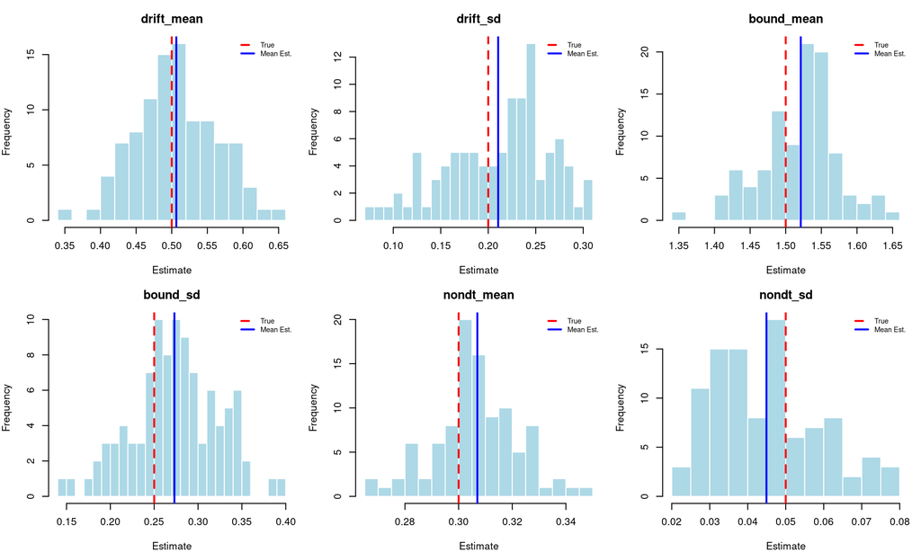

```r
#===============================================================================
# Visualization: Population parameter recovery
#===============================================================================
par(mfrow = c(2, 3), mar = c(4, 4, 3, 1))

for (i in 1:6) {
    param_name <- rownames(pop_estimates)[i]
    hist(pop_estimates[i, ], breaks = 20, main = param_name,
         xlab = "Estimate", col = "lightblue", border = "white")
    abline(v = true_pop[i], col = "red", lwd = 2, lty = 2)
    abline(v = mean(pop_estimates[i, ]), col = "blue", lwd = 2)
    legend("topright", c("True", "Mean Est."), col = c("red", "blue"),
           lty = c(2, 1), lwd = 2, cex = 0.7, bty = "n")
}
```

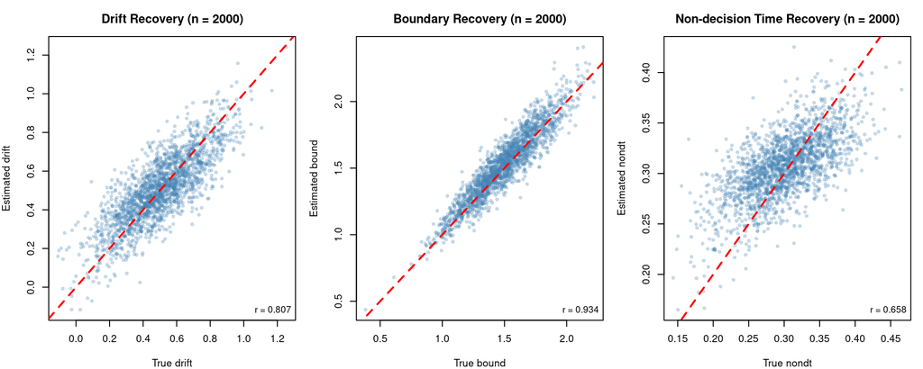

```r
#===============================================================================
# Visualization: Individual parameter recovery (across all datasets)
#===============================================================================

# Flatten 3D arrays to vectors (P participants x K datasets = P*K points)
true_drift_all <- as.vector(true_individual[, "drift", ])
true_bound_all <- as.vector(true_individual[, "bound", ])
true_nondt_all <- as.vector(true_individual[, "nondt", ])

est_drift_all <- as.vector(ind_estimates[, "drift", ])
est_bound_all <- as.vector(ind_estimates[, "bound", ])
est_nondt_all <- as.vector(ind_estimates[, "nondt", ])

par(mfrow = c(1, 3), mar = c(4, 4, 3, 1))

# Drift
plot(true_drift_all, est_drift_all,
     xlab = "True drift", ylab = "Estimated drift",
     main = paste0("Drift Recovery (n = ", P*K, ")"),
     pch = 16, col = rgb(0.27, 0.51, 0.71, 0.3), cex = 0.8)
abline(0, 1, col = "red", lwd = 2, lty = 2)
legend("bottomright", legend = paste("r =", round(cor(true_drift_all, est_drift_all), 3)),
       bty = "n", cex = 0.9)

# Bound
plot(true_bound_all, est_bound_all,
     xlab = "True bound", ylab = "Estimated bound",
     main = paste0("Boundary Recovery (n = ", P*K, ")"),
     pch = 16, col = rgb(0.27, 0.51, 0.71, 0.3), cex = 0.8)
abline(0, 1, col = "red", lwd = 2, lty = 2)
legend("bottomright", legend = paste("r =", round(cor(true_bound_all, est_bound_all), 3)),
       bty = "n", cex = 0.9)

# Non-decision time
plot(true_nondt_all, est_nondt_all,
     xlab = "True nondt", ylab = "Estimated nondt",
     main = paste0("Non-decision Time Recovery (n = ", P*K, ")"),
     pch = 16, col = rgb(0.27, 0.51, 0.71, 0.3), cex = 0.8)
abline(0, 1, col = "red", lwd = 2, lty = 2)
legend("bottomright", legend = paste("r =", round(cor(true_nondt_all, est_nondt_all), 3)),
       bty = "n", cex = 0.9)
```

```r
#===============================================================================
# Correlation between true and estimated individual parameters (all datasets)
#===============================================================================
cors_trialLevel <- data.frame(
    param = c("drift", "bound", "nondt"),
    correlation = c(
        cor(as.vector(true_individual[, "drift", ]), as.vector(ind_estimates[, "drift", ])),
        cor(as.vector(true_individual[, "bound", ]), as.vector(ind_estimates[, "bound", ])),
        cor(as.vector(true_individual[, "nondt", ]), as.vector(ind_estimates[, "nondt", ]))
    )
)

print(cors_trialLevel, digits = 3)
```

```
##   param correlation
## 1 drift       0.807
## 2 bound       0.934
## 3 nondt       0.658
```

## Simulation study 2: Direct summary statistics generation

In this simulation study, we generate summary statistics directly from their theoretical sampling distributions, bypassing trial-level data generation. While computationally faster, this method may inflate parameter recovery performance because the generated data perfectly follows the model’s assumed sampling distributions which assume independence between all summary statistics.

### Source custom functions

```r
# Source the function for direct summary statistics generation
source(here("JAGS", "src", "generate_sumStats.R"))
```

### Data generation

```r
#===============================================================================
# Generate or load simulated data (directly sampled summary statistics)
#===============================================================================

# File path for cached data
dataFile_direct <- here("JAGS", "demos", "simulation-study", "simplest_model",
                        paste0("simData_directSumStats_P", P, "_T", nTrials, "_K", K, ".RData"))

# IF cached data exists, load them
#####################################!!!
if (file.exists(dataFile_direct)) {

    load(dataFile_direct)

# ELSE, generate new data using direct sampling
#####################################!!!
} else {

    # Initialize 3D array to store summary statistics
    sumStats_direct <- array(NA, dim = c(P, 5, K),
                              dimnames = list(
                                  participant = 1:P,
                                  stat = c("sub", "nTrials", "sum_correct", "meanRT", "varRT"),
                                  dataset = 1:K))

    # Loop over K datasets
    for (k in 1:K) {

        set.seed(k + 5000)
        #-----------------------------------------------------------------------
        # Use true individual parameters from Simulation Study 1
        #-----------------------------------------------------------------------
        drift_true <- true_individual[, "drift", k]
        bound_true <- true_individual[, "bound", k]
        nondt_true <- true_individual[, "nondt", k]

        #-----------------------------------------------------------------------
        # Generate summary statistics DIRECTLY from sampling distributions
        #-----------------------------------------------------------------------
        true_pars_df <- data.frame(
            sub   = 1:P,
            drift = drift_true,
            bound = bound_true,
            nondt = nondt_true
        )

        sumstats <- generate_sumStats(true_pars_df, nTrials = nTrials)

        # Store in 3D array
        sumStats_direct[, "sub", k]         <- sumstats[, "sub"]
        sumStats_direct[, "nTrials", k]     <- nTrials
        sumStats_direct[, "sum_correct", k] <- sumstats[, "sum_correct"]
        sumStats_direct[, "meanRT", k]      <- sumstats[, "meanRT"]
        sumStats_direct[, "varRT", k]       <- sumstats[, "varRT"]

        # Progress indicator
        if (k %% 10 == 0) cat("Dataset", k, "of", K, "complete\n")
    }

    # Save to .RData file (no need to save true_individual, it's from Study 1)
    save(sumStats_direct, P, nTrials, K, file = dataFile_direct)
}
```

### Inspect generated data

Let us look at the accuracy rates observed across all datasets for a qucik comparison.

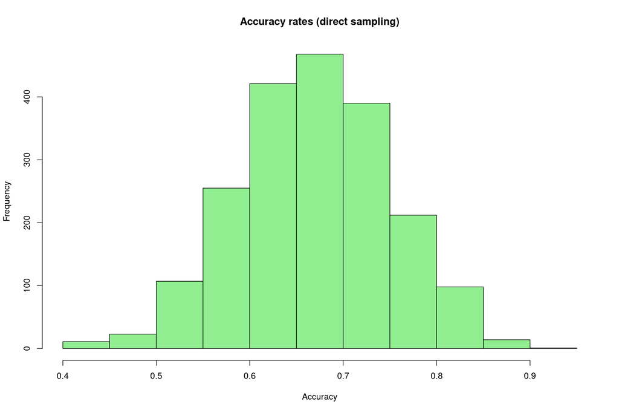

```r
# Check distribution of accuracy rates across all datasets
accuracy_rates_direct <- sumStats_direct[, "sum_correct", ] / nTrials
hist(accuracy_rates_direct, main = "Accuracy rates (direct sampling)",
     xlab = "Accuracy", col = "lightgreen")
```

The mean accuracy rate observed across all datasets is 0.674 with a standard deviation of 0.081 and a range of 0.4 to 0.93.

### Model fitting

```r
#===============================================================================
# Fit model or load cached results (direct summary statistics)
#===============================================================================

# File path for cached results
resultsFile_direct <- here("JAGS", "demos", "simulation-study", "simplest_model",
                           paste0("simResults_directSumStats_P", P, "_T", nTrials, "_K", K, ".RData"))

# Check if cached results exist
if (file.exists(resultsFile_direct)) {

    load(resultsFile_direct)

} else {

    # JAGS sampling settings (same as Simulation Study 1)
    n.chains  <- 4
    n.iter    <- 5000
    n.burnin  <- 1000
    n.thin    <- 1

    # Parameters to monitor
    parameters <- c('drift_mean', 'drift_sd', 'bound_mean', 'bound_sd',
                    'nondt_mean', 'nondt_sd', 'drift', 'bound', 'nondt')

    # Initialize storage arrays
    pop_estimates_direct <- array(NA, dim = c(6, K),
                                   dimnames = list(param = c("drift_mean", "drift_sd",
                                                             "bound_mean", "bound_sd",
                                                             "nondt_mean", "nondt_sd"),
                                                   dataset = 1:K))

    ind_estimates_direct <- array(NA, dim = c(P, 3, K),
                                   dimnames = list(participant = 1:P,
                                                   param = c("drift", "bound", "nondt"),
                                                   dataset = 1:K))

    rhat_max_direct <- numeric(K)

    # Fit model to all K datasets
    for (k in 1:K) {
        set.seed(k + 1000)

        # Prepare data for JAGS
        data_toJAGS <- list(
            N        = P,
            nTrials  = rep(nTrials, P),
            correct  = sumStats_direct[, "sum_correct", k],
            meanRT   = sumStats_direct[, "meanRT", k],
            varRT    = sumStats_direct[, "varRT", k]
        )

        # Initial values
        myinits <- replicate(n.chains, list(
            drift = rnorm(P, 0.5, 0.1),
            bound = runif(P, 1.0, 2.0),
            nondt = runif(P, 0.2, 0.4)
        ), simplify = FALSE)

        # Run JAGS
        samples <- jags(data = data_toJAGS,
                        parameters.to.save = parameters,
                        model.file = modelFile,
                        n.chains = n.chains, n.iter = n.iter,
                        n.burnin = n.burnin, n.thin = n.thin,
                        DIC = FALSE, inits = myinits)

        # Extract posterior means
        sims <- samples$BUGSoutput$sims.matrix
        pop_estimates_direct["drift_mean", k] <- mean(sims[, "drift_mean"])
        pop_estimates_direct["drift_sd", k]   <- mean(sims[, "drift_sd"])
        pop_estimates_direct["bound_mean", k] <- mean(sims[, "bound_mean"])
        pop_estimates_direct["bound_sd", k]   <- mean(sims[, "bound_sd"])
        pop_estimates_direct["nondt_mean", k] <- mean(sims[, "nondt_mean"])
        pop_estimates_direct["nondt_sd", k]   <- mean(sims[, "nondt_sd"])

        for (p in 1:P) {
            ind_estimates_direct[p, "drift", k] <- mean(sims[, paste0("drift[", p, "]")])
            ind_estimates_direct[p, "bound", k] <- mean(sims[, paste0("bound[", p, "]")])
            ind_estimates_direct[p, "nondt", k] <- mean(sims[, paste0("nondt[", p, "]")])
        }

        # Convergence check
        rhats <- apply(samples$BUGSoutput$sims.array[, , 1:6], 3, getRhat)
        rhat_max_direct[k] <- max(rhats)

        if (k %% 10 == 0) cat("Dataset", k, "/", K, "| Max Rhat:", round(rhat_max_direct[k], 3), "\n")
    }

    # Save results
    save(pop_estimates_direct, ind_estimates_direct, rhat_max_direct,
         n.chains, n.iter, n.burnin, n.thin,
         file = resultsFile_direct)
}
```

```r
sum(rhat_max_direct < 1.05)
```

```
## [1] 100
```

We find that 100% of the 100 datasets converged (Rhat $<$ 1.05).

### Parameter recovery results

```r
#===============================================================================
# Population-level parameter recovery (direct sampling)
#===============================================================================
data.frame(true = true_pop,
           mean_est = apply(pop_estimates_direct, 1, mean),
           sd_est = apply(pop_estimates_direct, 1, sd),
           bias = apply(pop_estimates_direct, 1, mean) - true_pop)
```

```
##            true   mean_est     sd_est          bias
## drift_mean 0.50 0.50112344 0.05928254  0.0011234449
## drift_sd   0.20 0.20094349 0.05627768  0.0009434864
## bound_mean 1.50 1.49091843 0.04859758 -0.0090815750
## bound_sd   0.25 0.26528392 0.04343887  0.0152839242
## nondt_mean 0.30 0.30170524 0.02062590  0.0017052390
## nondt_sd   0.05 0.07047405 0.02324316  0.0204740540
```

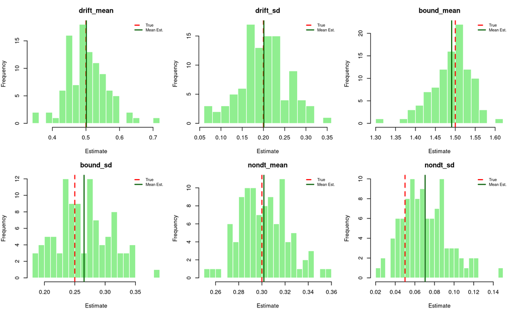

```r
#===============================================================================
# Visualization: Population parameter recovery (direct sampling)
#===============================================================================
par(mfrow = c(2, 3), mar = c(4, 4, 3, 1))

for (i in 1:6) {
    param_name <- rownames(pop_estimates_direct)[i]
    hist(pop_estimates_direct[i, ], breaks = 20, main = param_name,
         xlab = "Estimate", col = "lightgreen", border = "white")
    abline(v = true_pop[i], col = "red", lwd = 2, lty = 2)
    abline(v = mean(pop_estimates_direct[i, ]), col = "darkgreen", lwd = 2)
    legend("topright", c("True", "Mean Est."), col = c("red", "darkgreen"),
           lty = c(2, 1), lwd = 2, cex = 0.7, bty = "n")
}
```

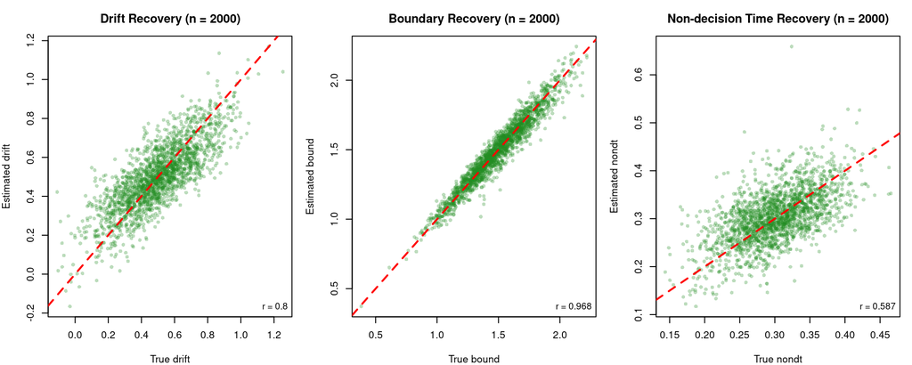

```r
#===============================================================================
# Visualization: Individual parameter recovery (direct sampling, all datasets)
#===============================================================================

# Flatten 3D arrays to vectors
# Use same true_individual from Simulation Study 1
true_drift_direct <- as.vector(true_individual[, "drift", ])
true_bound_direct <- as.vector(true_individual[, "bound", ])
true_nondt_direct <- as.vector(true_individual[, "nondt", ])

est_drift_direct <- as.vector(ind_estimates_direct[, "drift", ])
est_bound_direct <- as.vector(ind_estimates_direct[, "bound", ])
est_nondt_direct <- as.vector(ind_estimates_direct[, "nondt", ])

par(mfrow = c(1, 3), mar = c(4, 4, 3, 1))

# Drift
plot(true_drift_direct, est_drift_direct,
     xlab = "True drift", ylab = "Estimated drift",
     main = paste0("Drift Recovery (n = ", P*K, ")"),
     pch = 16, col = rgb(0.13, 0.55, 0.13, 0.3), cex = 0.8)
abline(0, 1, col = "red", lwd = 2, lty = 2)
legend("bottomright", legend = paste("r =", round(cor(true_drift_direct, est_drift_direct), 3)),
       bty = "n", cex = 0.9)

# Bound
plot(true_bound_direct, est_bound_direct,
     xlab = "True bound", ylab = "Estimated bound",
     main = paste0("Boundary Recovery (n = ", P*K, ")"),
     pch = 16, col = rgb(0.13, 0.55, 0.13, 0.3), cex = 0.8)
abline(0, 1, col = "red", lwd = 2, lty = 2)
legend("bottomright", legend = paste("r =", round(cor(true_bound_direct, est_bound_direct), 3)),
       bty = "n", cex = 0.9)

# Non-decision time
plot(true_nondt_direct, est_nondt_direct,
     xlab = "True nondt", ylab = "Estimated nondt",
     main = paste0("Non-decision Time Recovery (n = ", P*K, ")"),
     pch = 16, col = rgb(0.13, 0.55, 0.13, 0.3), cex = 0.8)
abline(0, 1, col = "red", lwd = 2, lty = 2)
legend("bottomright", legend = paste("r =", round(cor(true_nondt_direct, est_nondt_direct), 3)),
       bty = "n", cex = 0.9)
```

```r
#===============================================================================
# Correlation summary (direct sampling)
#===============================================================================
cors_direct <- data.frame(
    param = c("drift", "bound", "nondt"),
    correlation = c(
        cor(true_drift_direct, est_drift_direct),
        cor(true_bound_direct, est_bound_direct),
        cor(true_nondt_direct, est_nondt_direct)
    )
)

print(cors_direct, digits = 3)
```

```
##   param correlation
## 1 drift       0.800
## 2 bound       0.968
## 3 nondt       0.587
```

## Comparison: Trial-level vs Direct sampling

The model seems to perform similarly well when using trial-level data or directly sampled summary statistics in terms of the **individual-level** parameter recovery.

```r
#===============================================================================
# Compare parameter recovery between the two approaches
#===============================================================================

comparison <- data.frame(
    parameter = c("drift", "bound", "nondt"),
    r_trialLevel = cors_trialLevel$correlation,
    r_directSampling = cors_direct$correlation)

print(comparison, digits = 3)
```

```
##   parameter r_trialLevel r_directSampling
## 1     drift        0.807            0.800
## 2     bound        0.934            0.968
## 3     nondt        0.658            0.587
```

When we look at the **population-level** parameter recovery, we see that the model shows less biased estimates when using the directly sampled summary statistics.

```r
#===============================================================================
# Population-level bias comparison
#===============================================================================
bias_trialLevel <- apply(pop_estimates, 1, mean) - true_pop
bias_direct <- apply(pop_estimates_direct, 1, mean) - true_pop

bias_comparison <- data.frame(#parameter = names(true_pop),
                              bias_trialLevel = bias_trialLevel,
                              bias_direct = bias_direct)
print(bias_comparison, digits = 4)
```

```
##            bias_trialLevel bias_direct
## drift_mean        0.006416   0.0011234
## drift_sd          0.010458   0.0009435
## bound_mean        0.021102  -0.0090816
## bound_sd          0.023044   0.0152839
## nondt_mean        0.006983   0.0017052
## nondt_sd         -0.005075   0.0204741
```